## Assignment 5

### Xintong Li

#### Due Friday, October 2, 11:59pm CT

The purpose of this assignment is to give you practice using lubridate commands and to review dplyr, ggplot2, and basic exploratory data analysis skills.

Turn in an HTML file and this R Markdown file after you have edited it.

### 1

> Read in the five data sets. If needed, change the date variable into date format. (The date is recorded inconsistently across the data sets.) Use `bind_rows()` to combine these data sets into a single data set. Add columns for *year*, *month* (character valued, Jan-Dec), *day* (day of the month), and *wday* (day of the week, character valued, Sun - Sat). Reorder the variables so that these new variables all appear directly after date. Remove the terminal variable. Rename *all_total* to *passengers*, *all_flights* to *flights*, and *all_booths* to *booths*. Arrange the rows by date and hour. Remove the data sets from each individual year (use `rm()`).

> After these changes, how many rows and columns are in the complete data set?

```r
ORD_2015 = read.csv("ORD-2015.csv") %>%
  mutate(date = mdy(date))
ORD_2016 = read.csv("ORD-2016.csv") %>%
  mutate(date = mdy(date))
ORD_2017 = read.csv("ORD-2017.csv") %>%
  mutate(date = mdy(date))
ORD_2018 = read.csv("ORD-2018.csv") %>%
  mutate(date = mdy(date))
ORD_2019 = read.csv("ORD-2019.csv") %>%
  mutate(date = ymd(date))
ORD_2020 = read.csv("ORD-2020.csv") %>%
  mutate(date = mdy(date))
ORD_2021 = read.csv("ORD-2021.csv") %>%
  mutate(date = mdy(date))
ord = bind_rows(ORD_2015, ORD_2016, ORD_2017, ORD_2018, ORD_2019, ORD_2020, ORD_2021) %>%
  mutate(year = year(date), month = month(date, label = TRUE)) %>%
  mutate(day = day(date), wday = wday(date, label=TRUE)) %>%
  select(-terminal) %>%
  rename(passengers = all_total, flights = all_flights, booths = all_booths) %>%
  select(airport, date, year, month, day, wday, everything()) %>%
  arrange(date, hour)
rm(ORD_2015, ORD_2016, ORD_2017, ORD_2018, ORD_2019, ORD_2020, ORD_2021)
```

### 3

> Calculate the total numbers of flights and passengers in each month and year and store this information in a table. Summarize this table to find the total number of passengers and flights in each year from 2016 - 2019. Which year has the most of each?

#### Solution

```r
table = ord %>%
  group_by(month, year) %>%
  summarise(total_passengers = sum(passengers), total_flights = sum(flights))
print(table)
```

```
## # A tibble: 83 × 4
## # Groups:   month [12]
##    month  year total_passengers total_flights
##    <ord> <dbl>            <int>         <int>
##  1 Jan    2015           361035          2094
##  2 Jan    2016           382618          2200
##  3 Jan    2017           405301          2242
##  4 Jan    2018           438621          2392
##  5 Jan    2019           437663          2347
##  6 Jan    2020           440234          2276
##  7 Jan    2021           153888          1306
##  8 Feb    2015           274150          1823
##  9 Feb    2016           297269          2008
## 10 Feb    2017           304890          2025
## # … with 73 more rows
```

```r
max_pass = table %>%
  group_by(year) %>%
  summarise(total_passengers = sum(total_passengers), total_flights = sum(total_flights)) %>%
  arrange(desc(total_passengers))
print(max_pass)
```

```
## # A tibble: 7 × 3
##    year total_passengers total_flights
##   <dbl>            <int>         <int>
## 1  2019          5684548         29059
## 2  2018          5601907         29529
## 3  2017          5189091         28040
## 4  2016          4873212         26519
## 5  2015          4726907         26400
## 6  2021          2156376         15637
## 7  2020          1539933         11764
```

```r
max_flights = table %>%
  group_by(year) %>%
  summarise(total_passengers = sum(total_passengers), total_flights = sum(total_flights)) %>%
  arrange(desc(total_flights))
print(max_flights)
```

```
## # A tibble: 7 × 3
##    year total_passengers total_flights
##   <dbl>            <int>         <int>
## 1  2018          5601907         29529
## 2  2019          5684548         29059
## 3  2017          5189091         28040
## 4  2016          4873212         26519
## 5  2015          4726907         26400
## 6  2021          2156376         15637
## 7  2020          1539933         11764
```

- Year 2018 has the most of flights and year 2019 has the most of passengers.

> Display the total number of passengers by month and year with a bar chart where month is the primary variable on the x-axis and there is a separate bar (not stacked, and filled with a different color) for each year. Add meaningful axis and legend labels and a title to this graph. (See the layer in the section below which uses the `scale_fill_discrete()` function to control the legend title. In addition, `guides()` can offer even finer control over legend characteristics.) Change the scale on the y axis so that values are printed as numbers with commas and not using scientific notation. (See the help for the **ggplot2** function `scale_y_continuous()` and the **scales** function `label_comma()`.) Describe any patterns or interesting trends that you see.

#### Solution

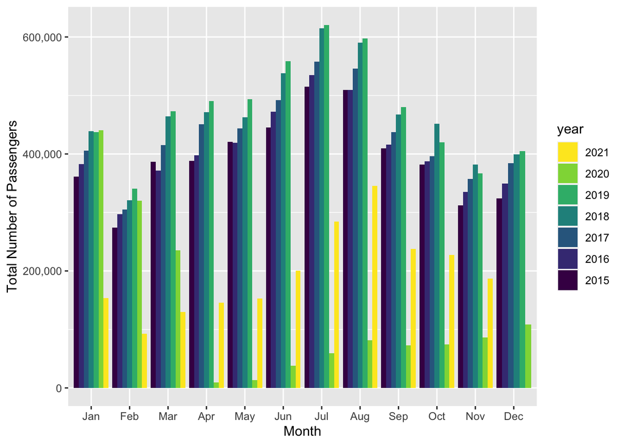

```r
ggplot(table, aes(x = month, y = total_passengers, fill = factor(year)))+
  scale_fill_discrete(guide = guide_legend(reverse=TRUE)) +
  geom_col(position="dodge")+
  labs(x = "Month", y = "Total Number of Passengers", fill = "year")+
  scale_y_continuous(labels = label_comma())
```

- From the plot we could see that the passengers’ number decreases a little from January to February and then increases until July. Finally, the number decrease again until November. Generally speaking, there are a lot of passengers during summer. However, in 2020, there are fewer passengers than before nearly every month.

### 5

> Add a `weekend` column to the combined data set which is TRUE for Saturdays and Sundays and FALSE for other days. Make a scatter plot with the average time for US passengers on the x-axis and the average time for non-US passengers on the y-axis. Use different colors for weekend and weekdays. Add a line to the plot that passes through the origin with a slope of one (explore `geom_abline()` to do this). Add straight regression lines to the plot, separately for weekends and weekdays (`geom_smooth()` with `method = "lm"`). Plot the data from different years in different facets. Change the color legend so that TRUE displays as “Weekend” and FALSE displays as “Weekday”. (Use `scale_color_discrete()` and experiment with the `name` and `labels` arguments. )

> Are there any noteworthy patterns to the data? What are the primary differences between domestic and international flyers and are the patterns different on weekdays versus weekends?

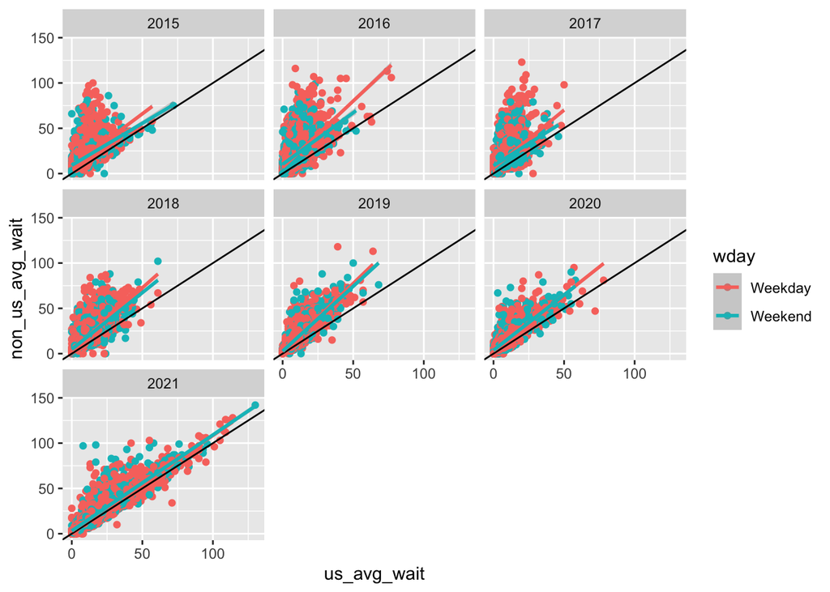

```r
new_weekend = ord %>%
  mutate(weekend = (wday == "Sun" | wday == "Sat"))

ggplot(new_weekend, aes(x = us_avg_wait,y=non_us_avg_wait,color=weekend)) +
  geom_point()+
  facet_wrap(~year)+
  geom_abline(slope = 1)+
  geom_smooth(method = "lm")+
  scale_color_discrete(name = "wday",labels = c("Weekday","Weekend"))
```

- Domestic flyers tend to spend less time on waiting than international flyers. And both US or non-US passengers tend to spend less time on waiting during weekends. However, non-US passengers still spend more time than US passengers.

### 6

> Calculate separately for each year, the fraction of cases (a case is a single hour on a single date) for which the average time to get through passport control is greater for non US passport holders than it is for passport holders. Comment on how these values relate to the graphs in the previous problem.

```r
frac_ord = ord %>%
  mutate(case = non_us_avg_wait>us_avg_wait)
frac_ord %>%
  group_by(year)%>%
  summarise(count = n(), rate = table(case)["TRUE"]/ count)
```

```
## # A tibble: 7 × 3
##    year count  rate
##   <dbl> <int> <dbl>
## 1  2015  6775 0.875
## 2  2016  6650 0.914
## 3  2017  6704 0.889
## 4  2018  7008 0.919
## 5  2019  6933 0.937
## 6  2020  4633 0.873
## 7  2021  5351 0.756
```

- It shows like nearly all non-US passengers spend more time waiting, so the line we get from the points is above the target line which slope is 1. The higher the rate, the upper the line above the target line.

### 7

> Add a column named `booth_rate` to the data set which estimates the average number of passengers per booth per hour. For example, if 1000 passengers arrive between 05:00 and 06:00, the average wait time is 40 minutes, and there are 10 booths open, then an estimate of the total number of passengers per booth per hour could be computed like this: 1000/10 = 100 passengers per booth; (40 minutes per passenger * 1 hour per 60 minutes) = 2/3 hours per passenger; booth rate = 100 / (2/3) = (1000 * 60) / (10 * 40) = 150 passengers per booth per hour. This is an estimate because it assumes available booths change on the hour and it ignores how rates change when passenger wait durations stretch into the next time period. Add another column called `time_of_day` which takes the value “overnight” from 1am to 5am, “early morning” from 5am to 8am, “morning” from 8am to noon, “afternoon” from noon to 5pm, and “early evening” from 5pm to 8pm, and “late evening” from 8pm to 1am. Use `reorder()` to put the `time_of_day` variable in this order.

> After calculating this statistic, filter out cases where there are fewer than 200 total passengers, the average wait time is zero, or the booth rate is over 500. Make side_by_side boxplots of the booth rate versus the day of the week using different colors for each day of the week, different facets for each time of day, and fill color white if it is a weekday and gray if it is on the weekend. **Hints:** Use `case_when()` to set values of the `time_of_day`. Use `scale_fill_manual()` to set the fill values to white or gray.

> Which time of day has the lowest booth rate? Do booth rates tend to be higher on the weekend or on weekdays during each time of day? Is this effect large or small relative to variation in the booth rate within a day of week and time of day?

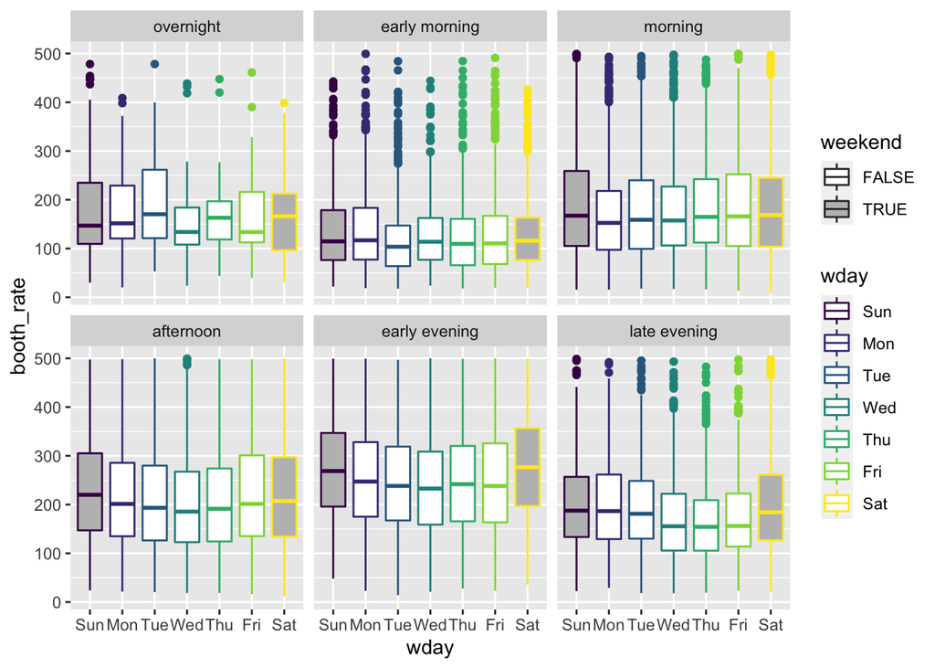

```r
plus_ord =  ord %>%
  mutate(booth_rate=(passengers/booths)/(all_avg_wait/60)) %>%
  mutate(time_of_day= case_when(
    hour== "0100 - 0200"| hour=="0200 - 0300"|hour=="0300 - 0400"|hour=="0400 - 0500" ~ "overnight",
    hour== "0500 - 0600"| hour=="0600 - 0700"|hour=="0700 - 0800" ~ "early morning",
    hour== "0800 - 0900"| hour=="0900 - 1000"|hour=="1000 - 1100"|hour=="1100 - 1200" ~ "morning",
    hour== "1200 - 1300"| hour=="1300 - 1400"|hour=="1400 - 1500"|hour=="1500 - 1600"|hour=="1600 - 1700"  ~ "afternoon",
    hour== "1700 - 1800"| hour=="1800 - 1900"|hour=="1900 - 2000"  ~"early evening",
    hour== "2000 - 2100"| hour=="2100 - 2200"|hour== "2200 - 2300"| hour=="2300 - 0000"|hour=="0000 - 0100" ~"late evening"))%>%
   mutate(index=case_when(
    time_of_day=="overnight"~1,
    time_of_day=="early morning"~2,
    time_of_day=="morning"~3,
    time_of_day=="afternoon"~4,
    time_of_day=="early evening"~5,
    time_of_day=="late evening"~6
  ))%>%
  mutate( time_of_day = reorder(time_of_day, index))%>%
  mutate(weekend = (wday == "Sun" | wday == "Sat")) %>%
  arrange(time_of_day)
plus_ord1 = plus_ord %>%
  filter(passengers>=200, all_avg_wait!=0, booth_rate<=500)
ggplot(plus_ord1, aes(x=wday,y=booth_rate, color = wday, fill = weekend))+
  geom_boxplot()+
  facet_wrap(~time_of_day)+
  scale_fill_manual(values=c("white","grey"))
```

```r
write.csv(plus_ord,'combined.csv')
```